# Лабораторная 2. Графика временных рядов

Раздел 2.10. Один и тот же розничный ряд (seed `20260930`) используется в лабах 2, 3, 5, 6 и 7.

```r
set.seed(20260930)
retail_id <- sample(aus_retail$`Series ID`, 1)
myseries <- aus_retail |>
  filter(`Series ID` == retail_id)
retail_id
```

```
## [1] "A3349574A"
```

## 1. Четыре ряда

```r
bricks <- aus_production |> select(Bricks) |> filter(!is.na(Bricks))
lynx <- pelt |> select(Lynx)
close <- gafa_stock |> select(Symbol, Date, Close)
demand <- vic_elec |> select(Demand)

interval(bricks)
```

```
## <interval[1]>
## [1] 1Q
```

```r
interval(lynx)
```

```
## <interval[1]>
## [1] 1Y
```

```r
interval(close)
```

```
## <interval[1]>
## [1] !
```

```r
interval(demand)
```

```
## <interval[1]>
## [1] 30m
```

Кирпич — квартал, рысь — год, цены закрытия — день (торговые дни, индекс нерегулярный), спрос Victoria — полчаса.

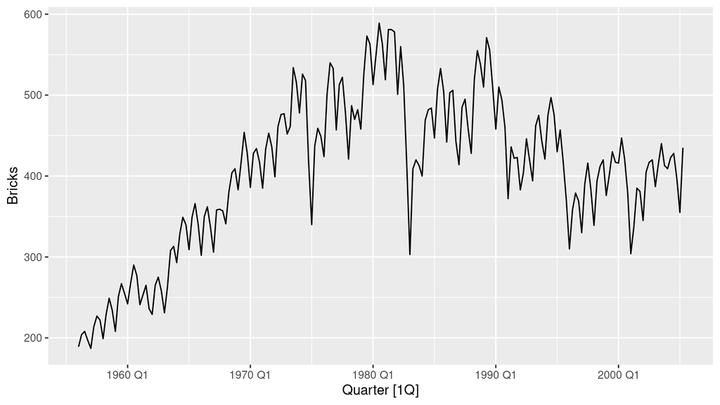

```r
autoplot(bricks, Bricks)
```

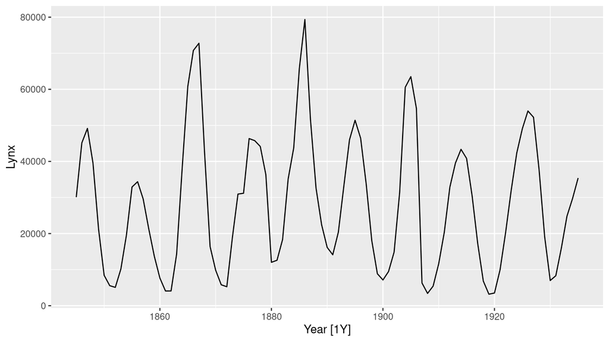

```r
autoplot(lynx, Lynx)
```

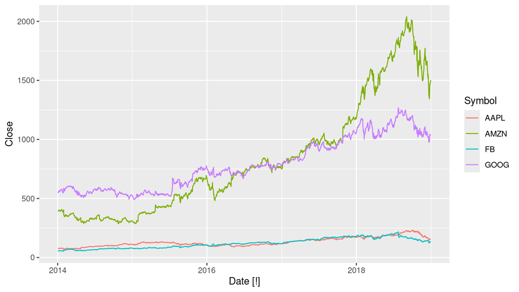

```r
autoplot(close, Close)
```

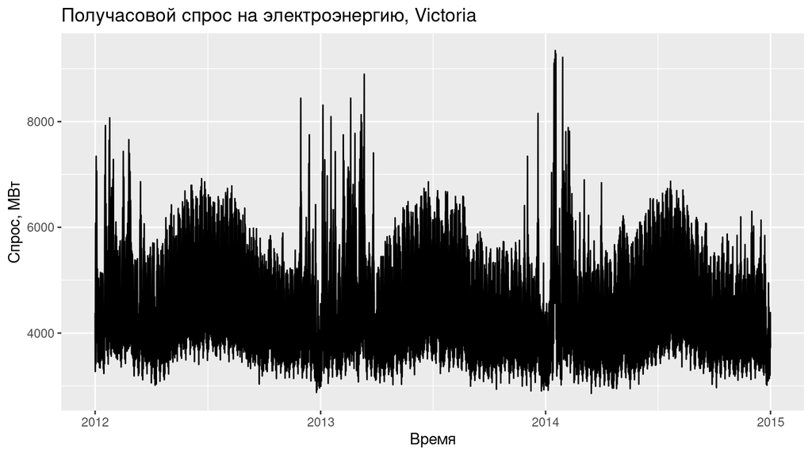

```r
autoplot(demand, Demand) +
  labs(title = "Получасовой спрос на электроэнергию, Victoria",
       y = "Спрос, МВт", x = "Время")
```

## 2. День максимума цены закрытия

```r
gafa_stock |>
  group_by(Symbol) |>
  filter(Close == max(Close)) |>
  select(Symbol, Date, Close) |>
  arrange(Symbol)
```

```
## # A tsibble: 4 x 3 [!]
## # Key:       Symbol [4]
## # Groups:    Symbol [4]
##   Symbol Date       Close
##   <chr>  <date>     <dbl>
## 1 AAPL   2018-10-03  232.
## 2 AMZN   2018-09-04 2040.
## 3 FB     2018-07-25  218.
## 4 GOOG   2018-07-26 1268.
```

## 3. tute1.csv

```r
tute1 <- readr::read_csv("data/tute1.csv")
mytimeseries <- tute1 |>
  mutate(Quarter = yearquarter(Quarter)) |>
  as_tsibble(index = Quarter)
mytimeseries
```

```
## # A tsibble: 100 x 4 [1Q]
##    Quarter Sales AdBudget   GDP
##      <qtr> <dbl>    <dbl> <dbl>
##  1 1981 Q1 1020.     659.  252.
##  2 1981 Q2  889.     589   291.
##  3 1981 Q3  795      512.  291.
##  4 1981 Q4 1004.     614.  292.
##  5 1982 Q1 1058.     647.  279.
##  6 1982 Q2  944.     602   254
##  7 1982 Q3  778.     531.  296.
##  8 1982 Q4  932.     608.  272.
##  9 1983 Q1  996.     638.  260.
## 10 1983 Q2  908.     582.  280.
## # ℹ 90 more rows
```

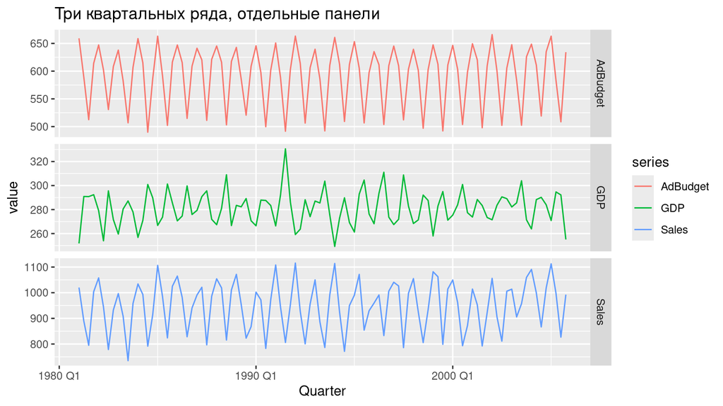

```r
long <- mytimeseries |>
  pivot_longer(-Quarter, names_to = "series", values_to = "value")
long |>
  ggplot(aes(Quarter, value, colour = series)) +
  geom_line() +
  facet_grid(series ~ ., scales = "free_y") +
  labs(title = "Три квартальных ряда, отдельные панели")
```

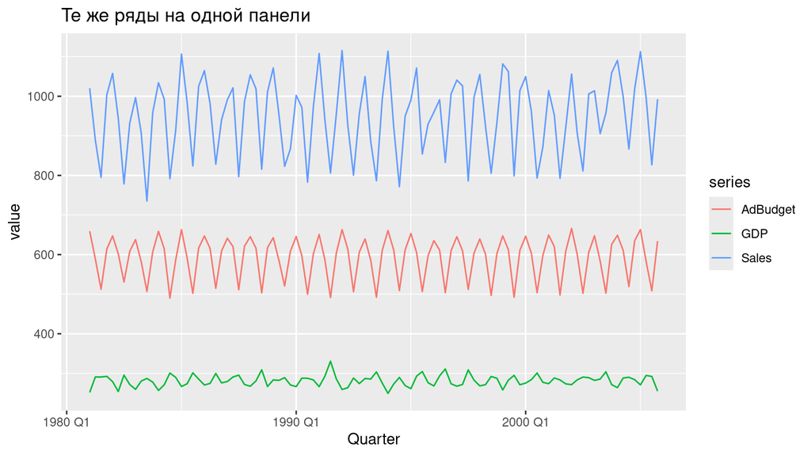

```r
long |>
  ggplot(aes(Quarter, value, colour = series)) +
  geom_line() +
  labs(title = "Те же ряды на одной панели")
```

## 4. Газ Новой Англии

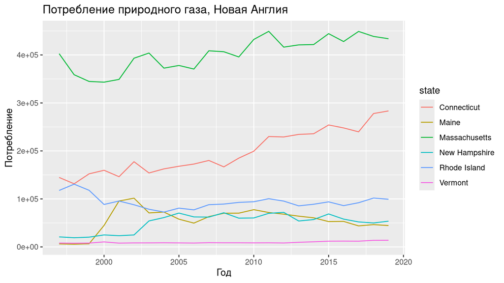

```r
new_england <- c("Maine", "Vermont", "New Hampshire",
                 "Massachusetts", "Connecticut", "Rhode Island")
us_total |>
  as_tsibble(index = year, key = state) |>
  filter(state %in% new_england) |>
  autoplot(y) +
  labs(title = "Потребление природного газа, Новая Англия",
       y = "Потребление", x = "Год")
```

## 5. tourism.xlsx

```r
tourism_xl <- readxl::read_excel("data/tourism.xlsx") |>
  mutate(Quarter = yearquarter(Quarter)) |>
  as_tsibble(index = Quarter, key = c(Region, State, Purpose))
all.equal(as_tibble(tourism_xl), as_tibble(tourism), check.attributes = FALSE)
```

```
## [1] TRUE
```

```r
tourism_xl |>
  as_tibble() |>
  group_by(Region, Purpose) |>
  summarise(avg_trips = mean(Trips), .groups = "drop") |>
  slice_max(avg_trips, n = 1)
```

```
## # A tibble: 1 × 3
##   Region Purpose  avg_trips
##   <chr>  <chr>        <dbl>
## 1 Sydney Visiting      747.
```

```r
tourism_state <- tourism_xl |>
  index_by(Quarter) |>
  group_by(State) |>
  summarise(Trips = sum(Trips)) |>
  ungroup()
tourism_state
```

```
## # A tsibble: 640 x 3 [1Q]
## # Key:       State [8]
##    State Quarter Trips
##    <chr>   <qtr> <dbl>
##  1 ACT   1998 Q1  551.
##  2 ACT   1998 Q2  416.
##  3 ACT   1998 Q3  436.
##  4 ACT   1998 Q4  450.
##  5 ACT   1999 Q1  379.
##  6 ACT   1999 Q2  558.
##  7 ACT   1999 Q3  449.
##  8 ACT   1999 Q4  595.
##  9 ACT   2000 Q1  600.
## 10 ACT   2000 Q2  557.
## # ℹ 630 more rows
```

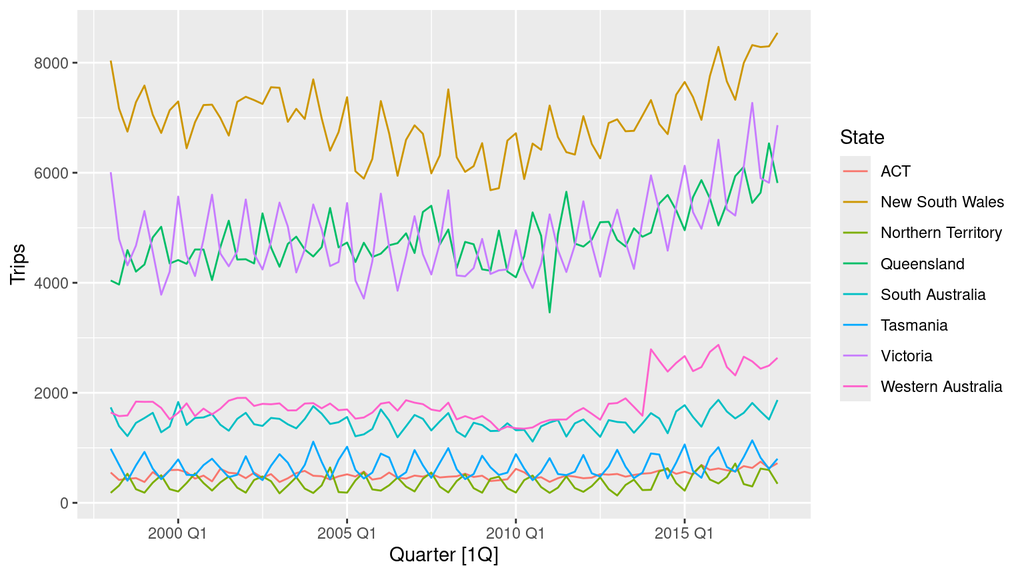

```r
autoplot(tourism_state, Trips)
```

## 6. Прибытия в Австралию

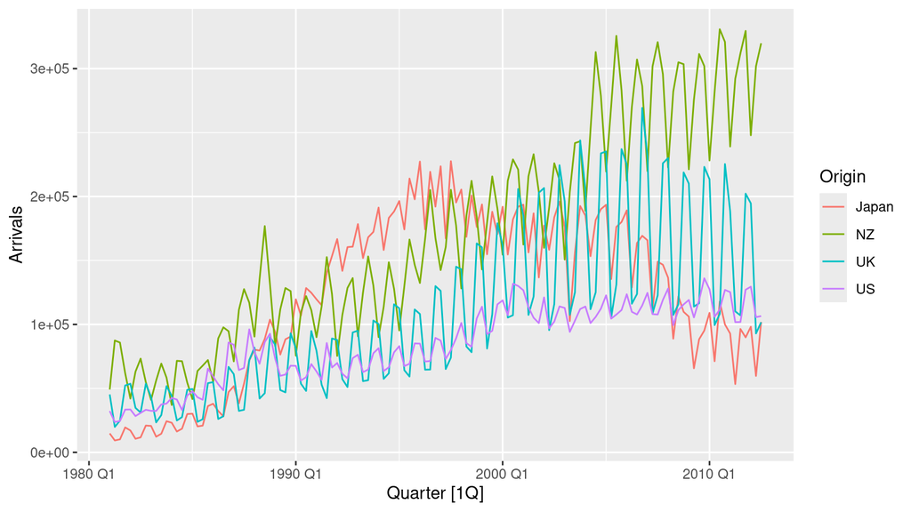

```r
autoplot(aus_arrivals, Arrivals)
```

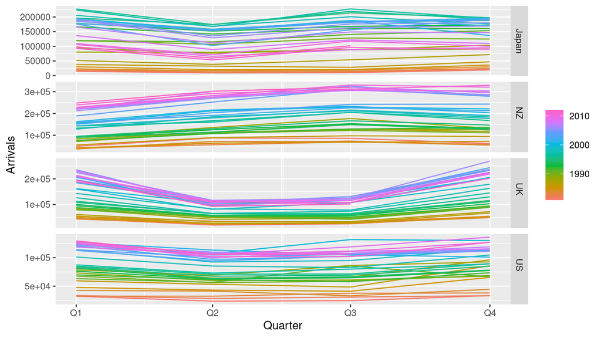

```r
gg_season(aus_arrivals, Arrivals)
```

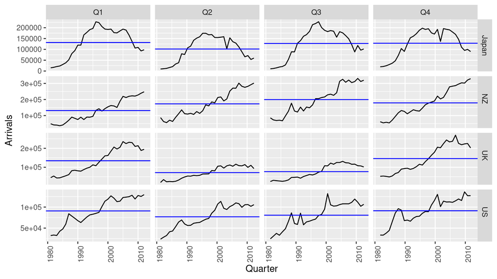

```r
gg_subseries(aus_arrivals, Arrivals)
```

У Японии виден подъём и спад, у Новой Зеландии — более ровный рост. Сезонность есть у всех четырёх: пик обычно в определённом квартале. Резкие провалы отдельных кварталов выделяются на графике подсерий.

## 7. Одна розничная серия

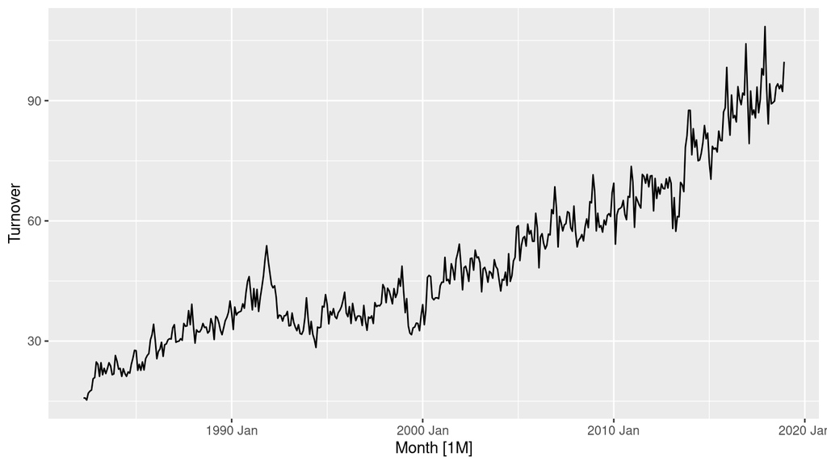

```r
autoplot(myseries, Turnover)
```

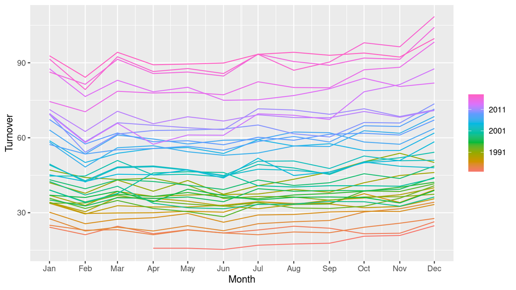

```r
gg_season(myseries, Turnover)
```

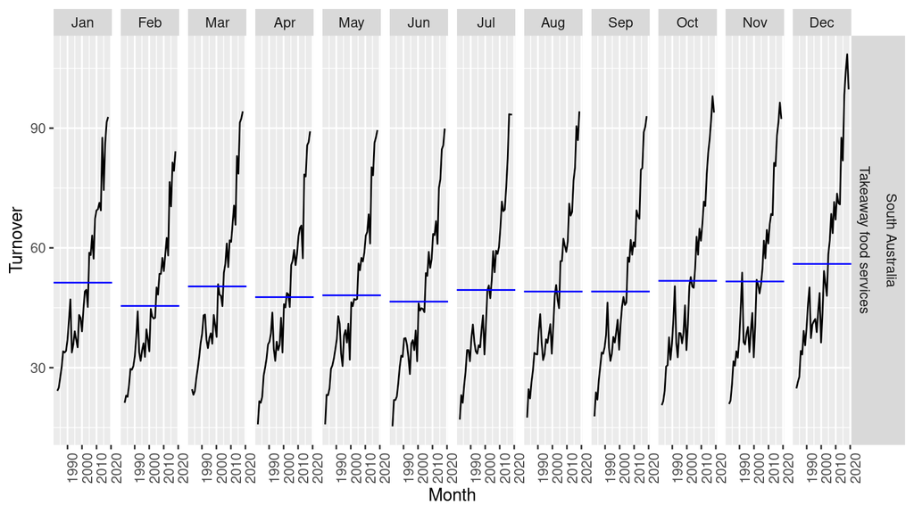

```r
gg_subseries(myseries, Turnover)
```

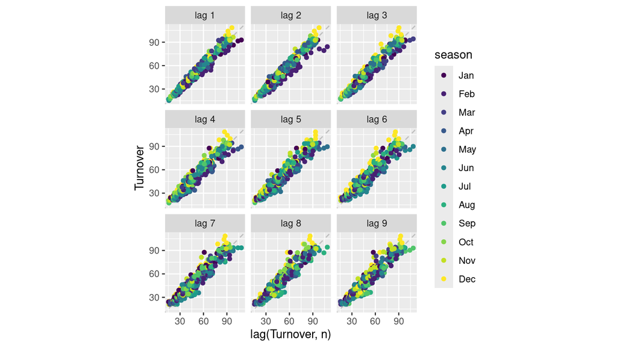

```r
gg_lag(myseries, Turnover, geom = "point")
```

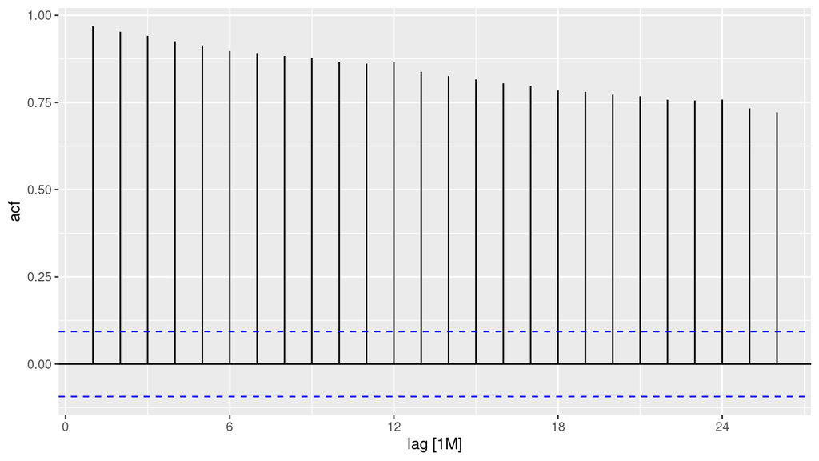

```r
myseries |> ACF(Turnover) |> autoplot()
```

Есть годовая сезонность (пики ACF на лагах 12, 24) и долгий тренд: ACF затухает медленно. Отдельного бизнес-цикла на этих графиках не видно, сезонная амплитуда со временем растёт.

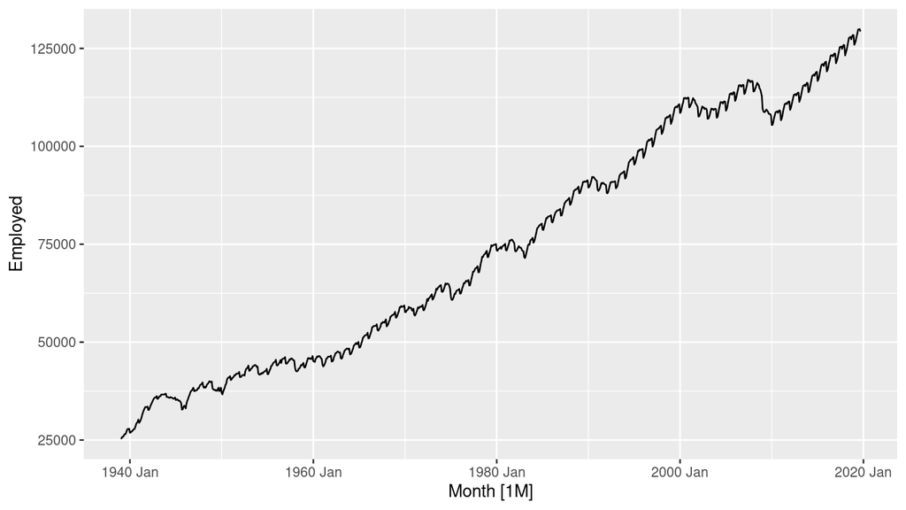

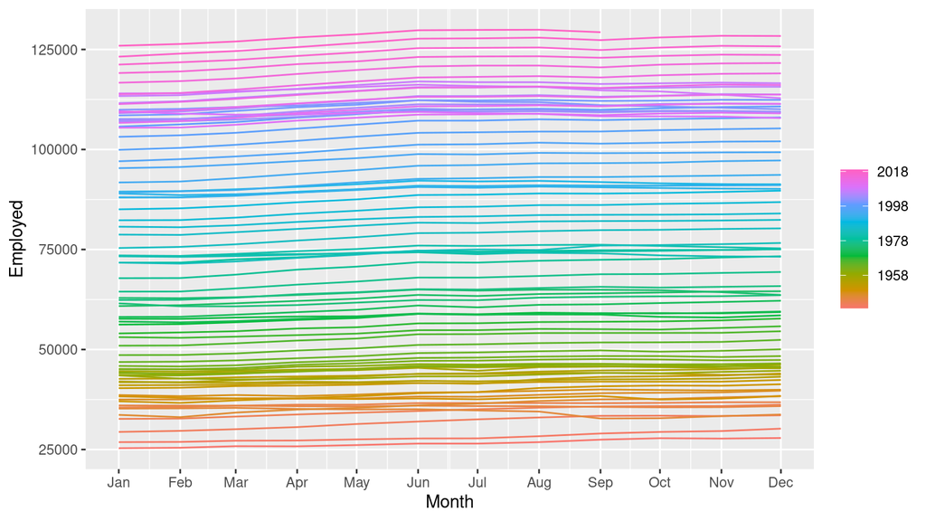

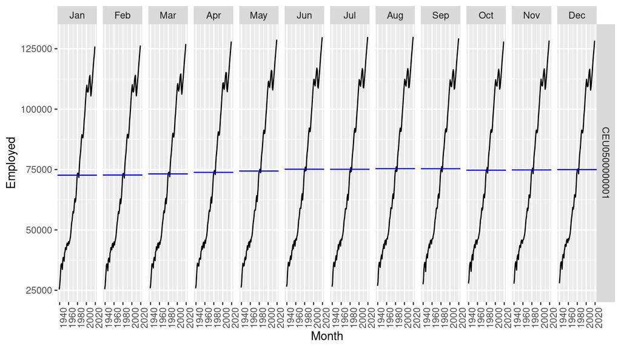

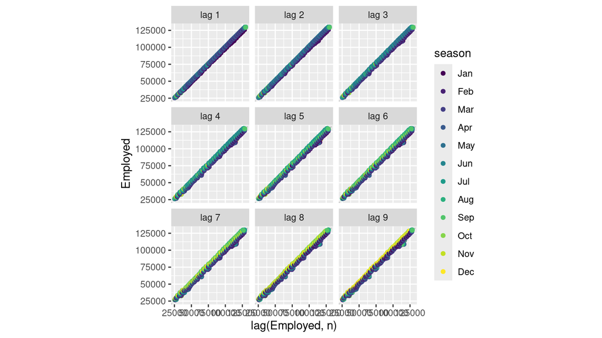

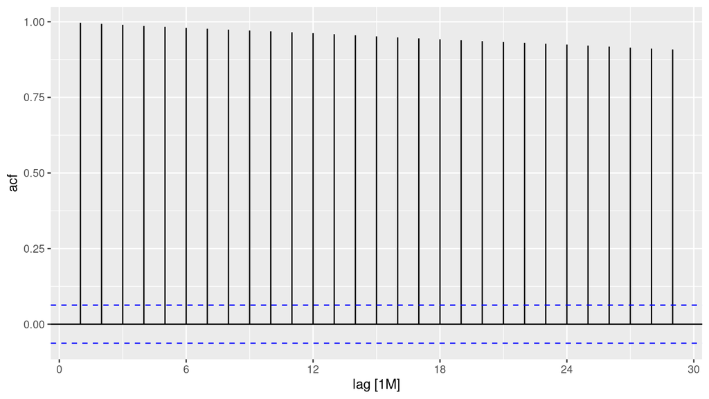

```r
private <- us_employment |> filter(Title == "Total Private")
h02 <- PBS |>
  filter(ATC2 == "H02") |>
  index_by(Month) |>
  summarise(Cost = sum(Cost))
hare <- pelt |> select(Hare)

explore <- function(data, y) {
  y <- enquo(y)
  print(autoplot(data, !!y))
  tryCatch(print(gg_season(data, !!y)),
           error = function(e) message("gg_season пропущен: ряд без сезонного периода"))
  tryCatch(print(gg_subseries(data, !!y)),
           error = function(e) message("gg_subseries пропущен: ряд без сезонного периода"))
  print(gg_lag(data, !!y, geom = "point"))
  print(data |> ACF(!!y) |> autoplot())
}
explore(private, Employed)
```

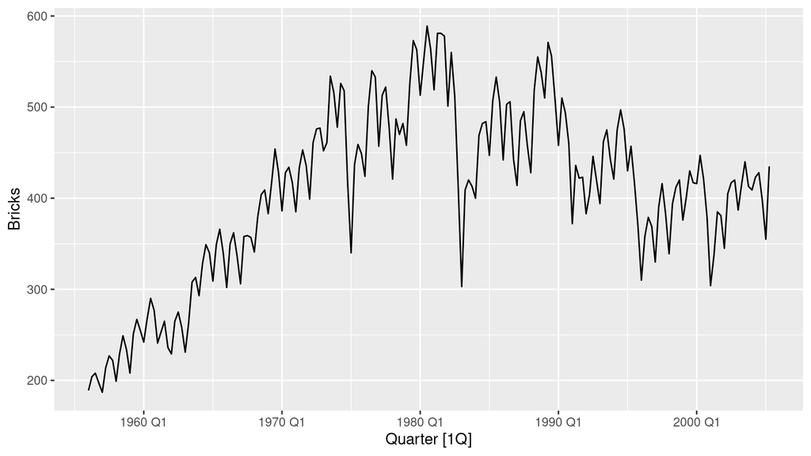

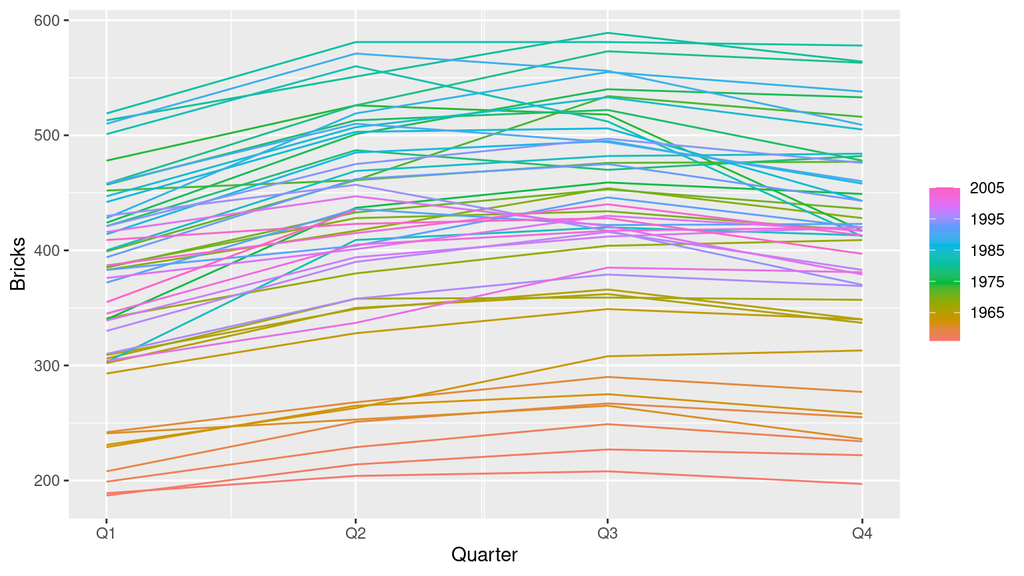

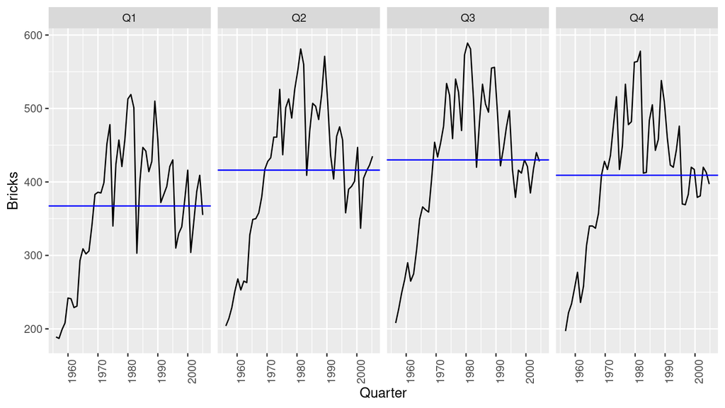

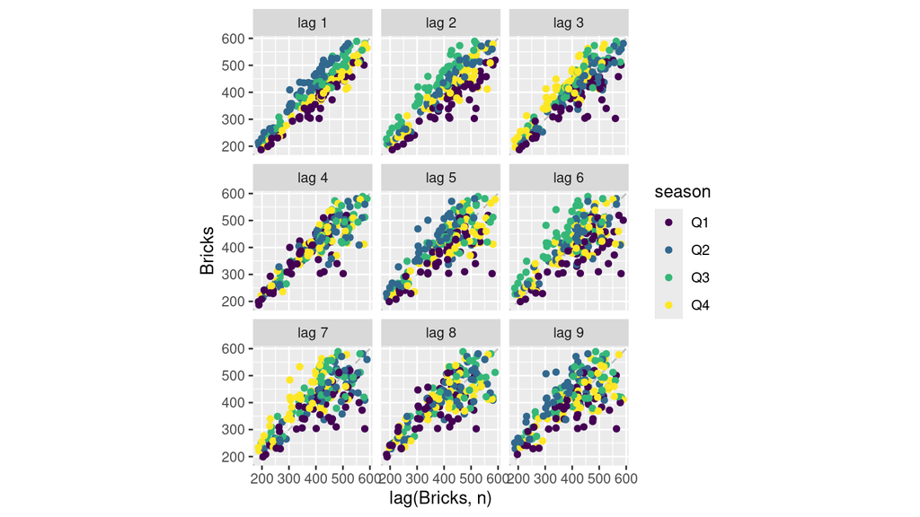

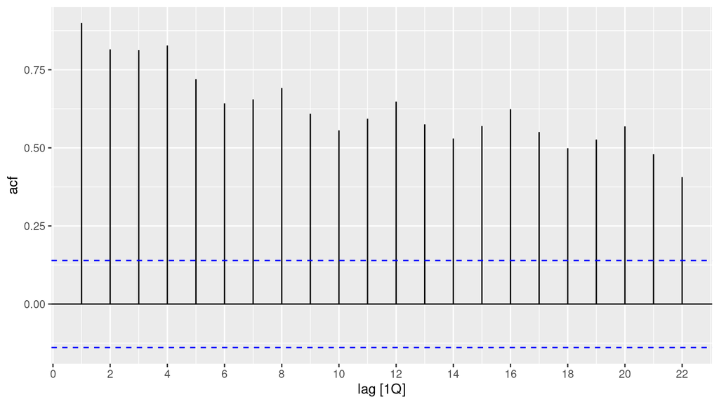

```r
explore(bricks, Bricks)
```

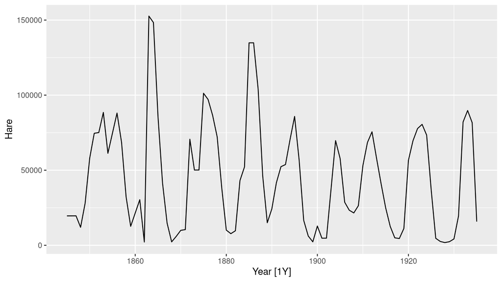

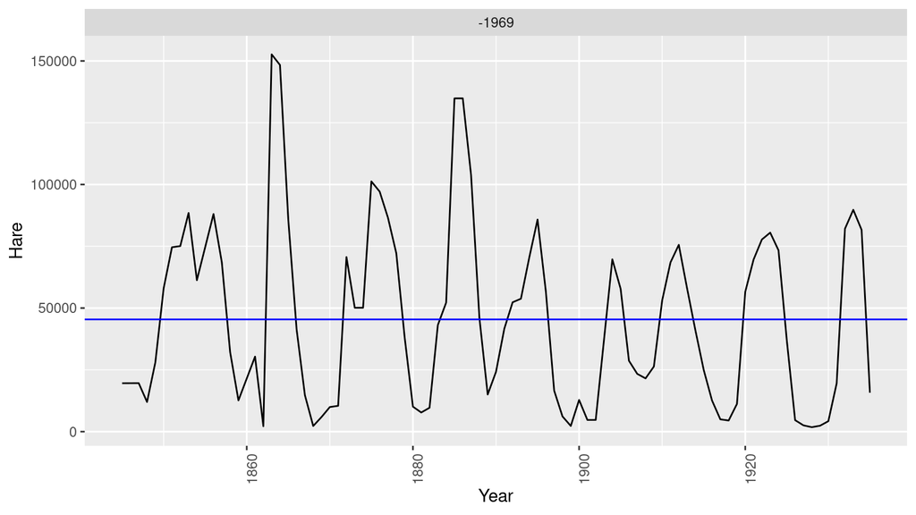

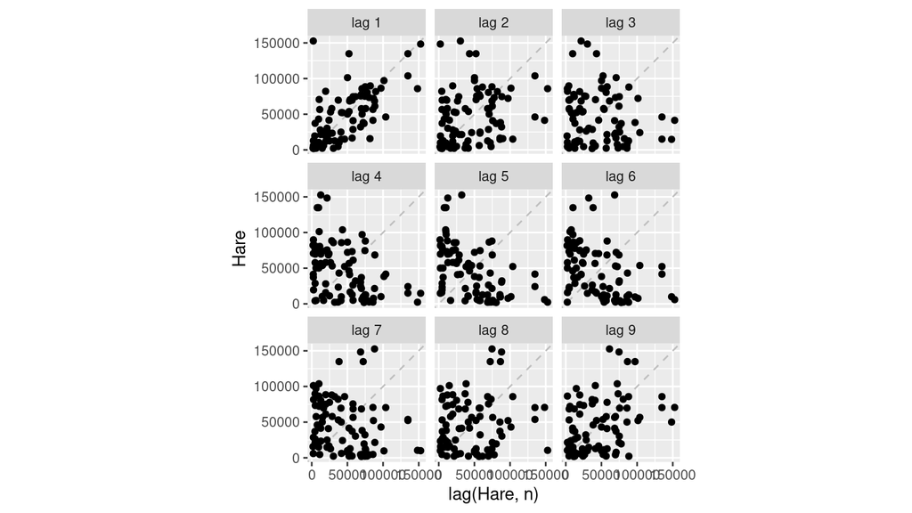

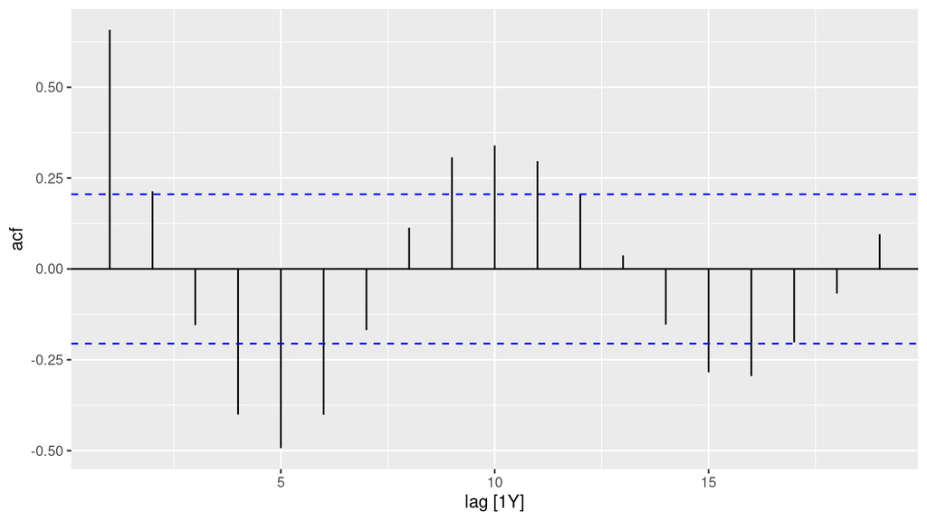

```r
explore(hare, Hare)
```